# **Smart Real Estate Insights Engine (SRIE)**

## **Project Overview**

I am building a **ML-driven pipeline** that can accurately predict rental prices while also providing **business-friendly insights** into real estate trends.  
Instead of just another price prediction model, I’m building something that truly **adds value**—a **Smart Real Estate Insights Engine (SRIE)** that:

- Predicts rent prices with high accuracy
- Explains the pricing factors behind each prediction
- Detects anomalies and pricing outliers
- Is cost-efficient, scalable, and easy to integrate

## **Next Steps**

- Load dependencies and set up the notebook
- Ensure modularity and efficiency before moving forward

```python
!pip install --upgrade --force-reinstall numpy pandas scikit-learn
```

[output not shown]

[output cut: 10 more lines]

[output not shown]

```python
!pip install category_encoders shap
```

[output not shown]

```python
!pip install catboost lightgbm xgboost
```

[output not shown]

```python
!pip install fastapi uvicorn optuna
```

[output not shown]

```python
# Core Libraries
import numpy as np
import os
import pandas as pd
import sqlite3
import warnings
import gdown
from google.colab import drive

# Visualization
import matplotlib.pyplot as plt
import seaborn as sns
import shap

# Machine Learning & Preprocessing
import catboost as cb
import lightgbm as lgb
import optuna
import xgboost as xgb
from category_encoders import BinaryEncoder
from sklearn.ensemble import RandomForestRegressor
from sklearn.linear_model import LinearRegression
from sklearn.metrics import mean_absolute_error, mean_squared_error, r2_score
from sklearn.model_selection import KFold, cross_val_score, train_test_split
from sklearn.preprocessing import MinMaxScaler, OneHotEncoder, StandardScaler
from sklearn.feature_selection import mutual_info_regression

# API & Deployment
from fastapi import FastAPI
from sqlalchemy import create_engine

# Settings
warnings.filterwarnings("ignore")
sns.set_style("whitegrid")
plt.rcParams["figure.figsize"] = (12, 5)
```

## **Data Ingestion**

I’ll be using **SQL-based data ingestion** to ensure seamless, real-time data integration. This ensures we can preprocess data at the database level, reducing overall compute costs.

- Loading training and testing datasets from **Google Drive**.
- Storing the data into a **SQLite database** for efficient querying.
- Ensuring that the database schema is well-structured for downstream analysis.

```python
# Mount Google Drive to access the dataset
drive.mount('/content/drive')
```

```python
# Define file paths
train_path = "/content/drive/MyDrive/ML_Projects/Smart_Real_Estate_Insights_Engine/data/train.csv"
test_path = "/content/drive/MyDrive/ML_Projects/Smart_Real_Estate_Insights_Engine/data/test.csv"
db_path = "/content/drive/MyDrive/ML_Projects/Smart_Real_Estate_Insights_Engine/data/real_estate_data.db"

# Load CSVs into DataFrames
train_df = pd.read_csv(train_path)
test_df = pd.read_csv(test_path)

# Connect to SQLite database (it will be created at the specified path if it doesn't exist)
conn = sqlite3.connect(db_path)

# Save DataFrames into the database
train_df.to_sql('train_data', conn, if_exists='replace', index=False)
test_df.to_sql('test_data', conn, if_exists='replace', index=False)

# Confirm shapes
print("Train Set Shape:", train_df.shape)
print("Test Set Shape:", test_df.shape)
```

```
Train Set Shape: (346479, 19)
Test Set Shape: (38498, 19)
```

## **Exploratory Data Analysis (EDA)**

Before proceeding with feature engineering and model training, I’ll conduct **exploratory data analysis** to understand the dataset, detect missing values, and identify key patterns.

- **Dataset Overview** → Checking the shape, summary statistics, and data types.
- **Missing Values Analysis** → Identifying missing values and deciding on imputation strategies.
- **Feature Distributions** → Visualizing numerical and categorical features.
- **Price Trends & Relationships** → Investigating how rent varies with key factors like **location, sq. footage, and amenities**.

```python
# Display basic dataset information
print(" Train Set Overview:")
display(train_df.info())
```

```
 Train Set Overview:
<class 'pandas.core.frame.DataFrame'>
RangeIndex: 346479 entries, 0 to 346478
Data columns (total 19 columns):
 #   Column                   Non-Null Count   Dtype
---  ------                   --------------   -----
 0   id                       346479 non-null  int64
 1   region                   346479 non-null  object
 2   price                    346479 non-null  int64
 3   type                     346479 non-null  object
 4   sqfeet                   346479 non-null  int64
 5   beds                     346479 non-null  int64
 6   baths                    346479 non-null  float64
 7   cats_allowed             346479 non-null  int64
 8   dogs_allowed             346479 non-null  int64
 9   smoking_allowed          346479 non-null  int64
 10  wheelchair_access        346479 non-null  int64
 11  electric_vehicle_charge  346479 non-null  int64
 12  comes_furnished          346479 non-null  int64
 13  laundry_options          275399 non-null  object
 14  parking_options          219914 non-null  object
 15  description              346477 non-null  object
 16  lat                      344728 non-null  float64
 17  long                     344728 non-null  float64
 18  state                    346479 non-null  object
dtypes: float64(3), int64(10), object(6)
memory usage: 50.2+ MB
```

```
None
```

```python
print("\n Test Set Overview:")
display(test_df.info())
```

```
 Test Set Overview:
<class 'pandas.core.frame.DataFrame'>
RangeIndex: 38498 entries, 0 to 38497
Data columns (total 19 columns):
 #   Column                   Non-Null Count  Dtype
---  ------                   --------------  -----
 0   id                       38498 non-null  int64
 1   region                   38498 non-null  object
 2   price                    38498 non-null  int64
 3   type                     38498 non-null  object
 4   sqfeet                   38498 non-null  int64
 5   beds                     38498 non-null  int64
 6   baths                    38498 non-null  float64
 7   cats_allowed             38498 non-null  int64
 8   dogs_allowed             38498 non-null  int64
 9   smoking_allowed          38498 non-null  int64
 10  wheelchair_access        38498 non-null  int64
 11  electric_vehicle_charge  38498 non-null  int64
 12  comes_furnished          38498 non-null  int64
 13  laundry_options          30552 non-null  object
 14  parking_options          24376 non-null  object
 15  description              38498 non-null  object
 16  lat                      38331 non-null  float64
 17  long                     38331 non-null  float64
 18  state                    38498 non-null  object
dtypes: float64(3), int64(10), object(6)
memory usage: 5.6+ MB
```

```
None
```

```python
# Show summary statistics
print("\n Summary Statistics (Train Set):")
display(train_df.describe())
```

```
 Summary Statistics (Train Set):
```

|  | id | price | sqfeet | beds | baths | cats_allowed | dogs_allowed | smoking_allowed | wheelchair_access | electric_vehicle_charge | comes_furnished | lat | long |
| --- | --- | --- | --- | --- | --- | --- | --- | --- | --- | --- | --- | --- | --- |
| count | 3.464790e+05 | 3.464790e+05 | 3.464790e+05 | 346479.000000 | 346479.000000 | 346479.000000 | 346479.000000 | 346479.000000 | 346479.000000 | 346479.000000 | 346479.000000 | 344728.000000 | 344728.000000 |
| mean | 7.040981e+09 | 1.615492e+03 | 1.067028e+03 | 1.904468 | 1.481110 | 0.726780 | 0.707847 | 0.731987 | 0.081939 | 0.012806 | 0.048040 | 37.237436 | -92.706870 |
| std | 8.798642e+06 | 6.586159e+04 | 2.018564e+04 | 3.256987 | 0.618514 | 0.445614 | 0.454753 | 0.442925 | 0.274272 | 0.112437 | 0.213852 | 5.542563 | 16.522223 |
| min | 7.003808e+09 | 0.000000e+00 | 0.000000e+00 | 0.000000 | 0.000000 | 0.000000 | 0.000000 | 0.000000 | 0.000000 | 0.000000 | 0.000000 | -43.533300 | -163.894000 |
| 25% | 7.035975e+09 | 8.060000e+02 | 7.500000e+02 | 1.000000 | 1.000000 | 0.000000 | 0.000000 | 0.000000 | 0.000000 | 0.000000 | 0.000000 | 33.465200 | -100.784000 |
| 50% | 7.043314e+09 | 1.039000e+03 | 9.500000e+02 | 2.000000 | 1.000000 | 1.000000 | 1.000000 | 1.000000 | 0.000000 | 0.000000 | 0.000000 | 37.658000 | -87.772500 |
| 75% | 7.048429e+09 | 1.395000e+03 | 1.150000e+03 | 2.000000 | 2.000000 | 1.000000 | 1.000000 | 1.000000 | 0.000000 | 0.000000 | 0.000000 | 41.141000 | -81.179600 |
| max | 7.051292e+09 | 2.170191e+07 | 8.388607e+06 | 1100.000000 | 75.000000 | 1.000000 | 1.000000 | 1.000000 | 1.000000 | 1.000000 | 1.000000 | 102.036000 | 172.633000 |

```python
print("\n Summary Statistics (Test Set):")
display(test_df.describe())
```

```
 Summary Statistics (Test Set):
```

|  | id | price | sqfeet | beds | baths | cats_allowed | dogs_allowed | smoking_allowed | wheelchair_access | electric_vehicle_charge | comes_furnished | lat | long |
| --- | --- | --- | --- | --- | --- | --- | --- | --- | --- | --- | --- | --- | --- |
| count | 3.849800e+04 | 3.849800e+04 | 38498.000000 | 38498.000000 | 38498.000000 | 38498.000000 | 38498.000000 | 38498.000000 | 38498.000000 | 38498.000000 | 38498.000000 | 38331.000000 | 38331.000000 |
| mean | 7.040987e+09 | 7.371723e+04 | 995.745389 | 1.913242 | 1.477194 | 0.727882 | 0.708556 | 0.729830 | 0.083667 | 0.013455 | 0.048912 | 37.197968 | -92.644517 |
| std | 8.816079e+06 | 1.410928e+07 | 610.390817 | 5.162276 | 0.613963 | 0.445056 | 0.454433 | 0.444053 | 0.276891 | 0.115215 | 0.215686 | 5.578459 | 16.619585 |
| min | 7.004010e+09 | 0.000000e+00 | 0.000000 | 0.000000 | 0.000000 | 0.000000 | 0.000000 | 0.000000 | 0.000000 | 0.000000 | 0.000000 | -22.151700 | -159.496000 |
| 25% | 7.036008e+09 | 8.050000e+02 | 750.000000 | 1.000000 | 1.000000 | 0.000000 | 0.000000 | 0.000000 | 0.000000 | 0.000000 | 0.000000 | 33.422600 | -99.769100 |
| 50% | 7.043347e+09 | 1.032000e+03 | 940.000000 | 2.000000 | 1.000000 | 1.000000 | 1.000000 | 1.000000 | 0.000000 | 0.000000 | 0.000000 | 37.520000 | -87.677900 |
| 75% | 7.048409e+09 | 1.395000e+03 | 1142.000000 | 2.000000 | 2.000000 | 1.000000 | 1.000000 | 1.000000 | 0.000000 | 0.000000 | 0.000000 | 41.132650 | -81.179600 |
| max | 7.051289e+09 | 2.768307e+09 | 50000.000000 | 1000.000000 | 35.000000 | 1.000000 | 1.000000 | 1.000000 | 1.000000 | 1.000000 | 1.000000 | 102.036000 | 94.124800 |

## **Handling Missing Data**

```python
# Check for missing values
missing_values = train_df.isnull().sum()
missing_values = missing_values[missing_values > 0].sort_values(ascending=False)

# Display missing values
print("Missing Values Per Column:\n", missing_values)
```

```
Missing Values Per Column:
 parking_options    126565
laundry_options     71080
lat                  1751
long                 1751
description             2
dtype: int64
```

### Approach for Handling Missing Values:

- Categorical Features:
  - Fill missing laundry_options and parking_options with "unknown" to preserve information without introducing bias.
- Numerical Features:
  - Fill missing lat and long with the median of their respective region to maintain geographical accuracy.
  - Compute price_per_sqft based on price and sqfeet where possible; otherwise, use median price per sqft from similar properties

```python
# Filling categorical missing values
train_df["laundry_options"].fillna("unknown", inplace=True)
train_df["parking_options"].fillna("unknown", inplace=True)

# Fill missing lat/long using regional median values
train_df["lat"] = train_df["lat"].fillna(train_df.groupby("region")["lat"].transform("median"))
train_df["long"] = train_df["long"].fillna(train_df.groupby("region")["long"].transform("median"))

# Compute price_per_sqft where missing
train_df["price_per_sqft"] = train_df["price"] / train_df["sqfeet"]
median_price_sqft = train_df.groupby("region")["price_per_sqft"].median()

# Apply median price per sqft for missing values
train_df.loc[train_df["price_per_sqft"].isnull(), "price_per_sqft"] = train_df["region"].map(median_price_sqft)

# Verifying if missing values are handled
missing_values_after = train_df.isnull().sum()
print("Missing Values After Cleaning:\n", missing_values_after[missing_values_after > 0])
```

```
Missing Values After Cleaning:
 description    2
dtype: int64
```

Since the description column is unlikely to be used directly in our ML pipeline, we can safely replace missing values with "No description provided" to maintain dataset consistency.

```python
# Fill missing descriptions with a placeholder text
train_df["description"].fillna("No description provided", inplace=True)

# Verify that no missing values remain
missing_values_final = train_df.isnull().sum()
print("Final Missing Values:\n", missing_values_final[missing_values_final > 0])
```

```
Final Missing Values:
 Series([], dtype: int64)
```

## **Feature Engineering & Transformation**

To improve the model’s predictive power, I’ll create **new features** and transform existing ones to ensure they are **model-ready**. This includes:

- Deriving meaningful **property-specific metrics** like `price_per_sqft`.
- Encoding **categorical variables** to numerical format.
- Scaling numerical features to **standardize values** across different scales.
- Ensuring that feature selection aligns with **business needs**.

```python
# Feature: Price per Bedroom
train_df["price_per_bed"] = train_df["price"] / train_df["beds"]
train_df["price_per_bed"].replace([np.inf, -np.inf], np.nan, inplace=True)
train_df["price_per_bed"].fillna(train_df["price"].median(), inplace=True)

# Feature: Price per Bathroom
train_df["price_per_bath"] = train_df["price"] / train_df["baths"]
train_df["price_per_bath"].replace([np.inf, -np.inf], np.nan, inplace=True)
train_df["price_per_bath"].fillna(train_df["price"].median(), inplace=True)

# Feature: Pets Allowed Indicator
train_df["pets_allowed"] = (train_df["cats_allowed"] | train_df["dogs_allowed"]).astype(int)

# Feature: Total Amenities Count
train_df["total_amenities"] = (
    train_df["pets_allowed"] + train_df["smoking_allowed"] +
    train_df["wheelchair_access"] + train_df["electric_vehicle_charge"] +
    train_df["comes_furnished"]
)

# Feature: Number of Listings per Region
train_df["region_listings"] = train_df.groupby("region")["id"].transform("count")

# Display sample data
print("Feature Engineering Completed. Sample Data:")
display(train_df[["price_per_bed", "price_per_bath", "pets_allowed", "total_amenities", "region_listings"]].head())
```

```
Feature Engineering Completed. Sample Data:
```

|  | price_per_bed | price_per_bath | pets_allowed | total_amenities | region_listings |
| --- | --- | --- | --- | --- | --- |
| 0 | 1316.0 | 1316.0 | 1 | 1 | 2152 |
| 1 | 580.0 | 1160.0 | 1 | 2 | 419 |
| 2 | 631.0 | 1262.0 | 1 | 1 | 2346 |
| 3 | 930.5 | 930.5 | 1 | 2 | 2366 |
| 4 | 626.0 | 626.0 | 1 | 1 | 1086 |

```python
# Ensure no zero values before division
test_df["sqfeet"] = test_df["sqfeet"].replace(0, np.nan)
test_df["beds"] = test_df["beds"].replace(0, np.nan)
test_df["baths"] = test_df["baths"].replace(0, np.nan)

# Compute missing features
test_df["price_per_sqft"] = test_df["price"] / test_df["sqfeet"]
test_df["price_per_bed"] = test_df["price"] / test_df["beds"]
test_df["price_per_bath"] = test_df["price"] / test_df["baths"]
test_df["region_listings"] = test_df.groupby("region")["id"].transform("count")

# Handle NaN values by filling with median
test_df["price_per_sqft"].fillna(test_df["price_per_sqft"].median(), inplace=True)
test_df["price_per_bed"].fillna(test_df["price_per_bed"].median(), inplace=True)
test_df["price_per_bath"].fillna(test_df["price_per_bath"].median(), inplace=True)
test_df["region_listings"].fillna(test_df["region_listings"].median(), inplace=True)


# Confirm Fix
print("Fixed Missing Features in Test Set:")
display(test_df[["price_per_sqft", "price_per_bed", "price_per_bath", "region_listings"]].head())
```

```
Fixed Missing Features in Test Set:
```

|  | price_per_sqft | price_per_bed | price_per_bath | region_listings |
| --- | --- | --- | --- | --- |
| 0 | 1.869658 | 875.0 | 1750.0 | 152 |
| 1 | 0.708333 | 425.0 | 340.0 | 92 |
| 2 | 1.457726 | 750.0 | 1500.0 | 246 |
| 3 | 1.050234 | 449.5 | 899.0 | 211 |
| 4 | 1.700000 | 597.5 | 595.0 | 226 |

```python
# Compute pets_allowed in test set
test_df["pets_allowed"] = (test_df["cats_allowed"] | test_df["dogs_allowed"]).astype(int)

# Compute total_amenities in test set
test_df["total_amenities"] = (
    test_df["pets_allowed"] + test_df["smoking_allowed"] +
    test_df["wheelchair_access"] + test_df["electric_vehicle_charge"] +
    test_df["comes_furnished"]
)

# Verify
print("Fixed `pets_allowed` and `total_amenities` in Test Set:")
display(test_df[["pets_allowed", "total_amenities"]].head())
```

```
Fixed `pets_allowed` and `total_amenities` in Test Set:
```

|  | pets_allowed | total_amenities |
| --- | --- | --- |
| 0 | 1 | 2 |
| 1 | 0 | 0 |
| 2 | 1 | 1 |
| 3 | 1 | 2 |
| 4 | 0 | 0 |

### **Analyze Categorical Columns**

Before choosing an encoding strategy, let's examine:

- **Number of unique values** → Helps determine whether to use One-Hot, Binary, or Ordinal encoding.
- **Distribution of values** → Ensures balanced representation and avoids sparsity.
- **Potential impact on the model** → Avoiding unnecessary high-dimensionality.

```python
# Identify categorical columns
categorical_cols = train_df.select_dtypes(include=["object"]).columns.tolist()

# Count unique values for each categorical column
unique_counts = train_df[categorical_cols].nunique().sort_values()

# Display unique value counts
print("Unique Value Counts for Categorical Columns:")
display(unique_counts)
```

```
Unique Value Counts for Categorical Columns:
```

|  | 0 |
| --- | --- |
| laundry_options | 6 |
| parking_options | 8 |
| type | 12 |
| state | 51 |
| region | 404 |
| description | 254650 |

**dtype:** int64

### **Selecting Encoding Methods**

Given the unique value counts, here’s the optimal approach for each column:

1. **One-Hot Encode** → `laundry_options`, `parking_options`, and `type`.
2. **Binary Encode** → `state`.
3. **Feature Engineer `region`** → Instead of encoding all 404 values, we **use "region_listings" (number of listings per region)** to capture its impact.
4. **Drop or Process `description`** → If needed, we can use NLP-based embeddings.

```python
# Ensure test set has all required columns before encoding
missing_test_cols = set(train_df.columns) - set(test_df.columns)
print("Missing Columns in Test Set Before Encoding:", missing_test_cols)

# If any required columns are missing, recompute them
if missing_test_cols:
    raise ValueError("Some required features are still missing in the test set. Fix them before encoding!")
```

```
Missing Columns in Test Set Before Encoding: set()
```

```python
# One-Hot Encode low-cardinality features
low_cardinality_cols = ["laundry_options", "parking_options", "type"]
onehot_encoder = OneHotEncoder(drop="first", sparse_output=False, handle_unknown="ignore")

# Transform categorical features
encoded_features = pd.DataFrame(onehot_encoder.fit_transform(train_df[low_cardinality_cols]))
encoded_features.columns = onehot_encoder.get_feature_names_out(low_cardinality_cols)

# Binary Encode medium-cardinality feature (state)
binary_encoder = BinaryEncoder(cols=["state"])
binary_encoded = binary_encoder.fit_transform(train_df[["state"]])

# Drop original categorical columns & concatenate new encodings
train_df_encoded = train_df.drop(columns=low_cardinality_cols + ["state", "region", "description"])
train_df_encoded = pd.concat([train_df_encoded, encoded_features, binary_encoded], axis=1)

# Verify Encoding
print("Encoding Completed. New Dataset Shape:", train_df_encoded.shape)
display(train_df_encoded.head())
```

```
Encoding Completed. New Dataset Shape: (346479, 48)
```

|  | id | price | sqfeet | beds | baths | cats_allowed | dogs_allowed | smoking_allowed | wheelchair_access | electric_vehicle_charge | ... | type_land | type_loft | type_manufactured | type_townhouse | state_0 | state_1 | state_2 | state_3 | state_4 | state_5 |
| --- | --- | --- | --- | --- | --- | --- | --- | --- | --- | --- | --- | --- | --- | --- | --- | --- | --- | --- | --- | --- | --- |
| 0 | 7049965813 | 2632 | 1080 | 2 | 2.0 | 1 | 1 | 0 | 0 | 0 | ... | 0.0 | 0.0 | 0.0 | 0.0 | 0 | 0 | 0 | 0 | 0 | 1 |
| 1 | 7036046796 | 1160 | 768 | 2 | 1.0 | 1 | 1 | 1 | 0 | 0 | ... | 0.0 | 0.0 | 0.0 | 0.0 | 0 | 0 | 0 | 0 | 0 | 1 |
| 2 | 7037856890 | 1262 | 1075 | 2 | 1.0 | 1 | 1 | 0 | 0 | 0 | ... | 0.0 | 0.0 | 0.0 | 0.0 | 0 | 0 | 0 | 0 | 1 | 0 |
| 3 | 7046933042 | 1861 | 1076 | 2 | 2.0 | 1 | 1 | 0 | 0 | 1 | ... | 0.0 | 0.0 | 0.0 | 0.0 | 0 | 0 | 0 | 0 | 1 | 1 |
| 4 | 7048650961 | 626 | 720 | 1 | 1.0 | 1 | 1 | 0 | 0 | 0 | ... | 0.0 | 0.0 | 0.0 | 0.0 | 0 | 0 | 0 | 1 | 0 | 0 |

5 rows × 48 columns

```python
# Apply One-Hot Encoding to categorical features in test set
encoded_test_features = pd.DataFrame(onehot_encoder.transform(test_df[low_cardinality_cols]))
encoded_test_features.columns = onehot_encoder.get_feature_names_out(low_cardinality_cols)

# Apply Binary Encoding to test set
binary_encoded_test = binary_encoder.transform(test_df[["state"]])

# Drop original categorical columns & concatenate encodings
test_df_encoded = test_df.drop(columns=low_cardinality_cols + ["state", "region", "description"])
test_df_encoded = pd.concat([test_df_encoded, encoded_test_features, binary_encoded_test], axis=1)

print("Encoding Completed for Test Set. New Dataset Shape:", test_df_encoded.shape)
```

```
Encoding Completed for Test Set. New Dataset Shape: (38498, 48)
```

```python
# Verify alignment between train and test datasets
missing_cols_test = set(train_df_encoded.columns) - set(test_df_encoded.columns)
extra_cols_test = set(test_df_encoded.columns) - set(train_df_encoded.columns)

print("\nMissing in Test Set:", missing_cols_test)
print("Extra in Test Set:", extra_cols_test)

# Fix: Add missing columns as zeros (if needed)
for col in missing_cols_test:
    test_df_encoded[col] = 0

# Drop extra columns from test set (if any)
test_df_encoded = test_df_encoded[train_df_encoded.columns]

print("Final Test Set Shape After Fixing:", test_df_encoded.shape)
```

```
Missing in Test Set: set()
Extra in Test Set: set()
Final Test Set Shape After Fixing: (38498, 48)
```

### Distribution

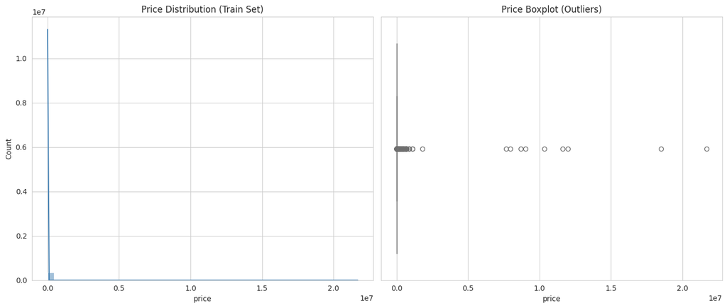

```python
fig, axes = plt.subplots(1, 2, figsize=(14, 6))

sns.histplot(train_df['price'], bins=50, kde=True, ax=axes[0], color="steelblue")
axes[0].set_title("Price Distribution (Train Set)")

sns.boxplot(x=train_df['price'], ax=axes[1], color="lightcoral")
axes[1].set_title("Price Boxplot (Outliers)")

plt.tight_layout()
plt.show()
```

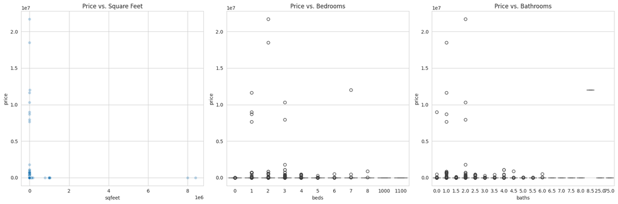

```python
fig, axes = plt.subplots(1, 3, figsize=(18, 6))

sns.scatterplot(x=train_df["sqfeet"], y=train_df["price"], alpha=0.3, ax=axes[0])
axes[0].set_title("Price vs. Square Feet")

sns.boxplot(x=train_df["beds"], y=train_df["price"], ax=axes[1])
axes[1].set_title("Price vs. Bedrooms")

sns.boxplot(x=train_df["baths"], y=train_df["price"], ax=axes[2])
axes[2].set_title("Price vs. Bathrooms")

plt.tight_layout()
plt.show()
```

## **Scaling Numerical Features**

To ensure that all numerical features are on a comparable scale, I will apply **Min-Max Scaling**, which normalizes values between `0 and 1`.

### **Why Min-Max Scaling?**

- Preserves relationships between variables.
- Prevents large values (like `price` and `sqfeet`) from dominating.
- Essential for models like **XGBoost, Linear Regression, and Neural Networks**.

### **Features to Scale**

- `sqfeet`, `beds`, `baths`
- `price_per_sqft`, `price_per_bed`, `price_per_bath`
- `region_listings` (number of listings in each region)

```python
# Identify numerical columns
numerical_cols = train_df_encoded.select_dtypes(include=["int64", "float64"]).columns.tolist()

# Display numerical feature summary
print("Numerical Columns in Dataset:")
#display(numerical_cols)

# Show summary statistics to assess scaling needs
print("\nSummary Statistics of Numerical Features:")
display(train_df_encoded[numerical_cols].describe())
```

```
Numerical Columns in Dataset:

Summary Statistics of Numerical Features:
```

|  | id | price | sqfeet | beds | baths | cats_allowed | dogs_allowed | smoking_allowed | wheelchair_access | electric_vehicle_charge | ... | type_land | type_loft | type_manufactured | type_townhouse | state_0 | state_1 | state_2 | state_3 | state_4 | state_5 |
| --- | --- | --- | --- | --- | --- | --- | --- | --- | --- | --- | --- | --- | --- | --- | --- | --- | --- | --- | --- | --- | --- |
| count | 3.464790e+05 | 3.464790e+05 | 3.464790e+05 | 346479.000000 | 346479.000000 | 346479.000000 | 346479.000000 | 346479.000000 | 346479.000000 | 346479.000000 | ... | 346479.000000 | 346479.000000 | 346479.000000 | 346479.000000 | 346479.000000 | 346479.000000 | 346479.000000 | 346479.000000 | 346479.000000 | 346479.000000 |
| mean | 7.040981e+09 | 1.615492e+03 | 1.067028e+03 | 1.904468 | 1.481110 | 0.726780 | 0.707847 | 0.731987 | 0.081939 | 0.012806 | ... | 0.000017 | 0.001836 | 0.011028 | 0.041356 | 0.201770 | 0.286736 | 0.500426 | 0.508640 | 0.454755 | 0.514753 |
| std | 8.798642e+06 | 6.586159e+04 | 2.018564e+04 | 3.256987 | 0.618514 | 0.445614 | 0.454753 | 0.442925 | 0.274272 | 0.112437 | ... | 0.004161 | 0.042805 | 0.104434 | 0.199113 | 0.401322 | 0.452238 | 0.500001 | 0.499926 | 0.497949 | 0.499783 |
| min | 7.003808e+09 | 0.000000e+00 | 0.000000e+00 | 0.000000 | 0.000000 | 0.000000 | 0.000000 | 0.000000 | 0.000000 | 0.000000 | ... | 0.000000 | 0.000000 | 0.000000 | 0.000000 | 0.000000 | 0.000000 | 0.000000 | 0.000000 | 0.000000 | 0.000000 |
| 25% | 7.035975e+09 | 8.060000e+02 | 7.500000e+02 | 1.000000 | 1.000000 | 0.000000 | 0.000000 | 0.000000 | 0.000000 | 0.000000 | ... | 0.000000 | 0.000000 | 0.000000 | 0.000000 | 0.000000 | 0.000000 | 0.000000 | 0.000000 | 0.000000 | 0.000000 |
| 50% | 7.043314e+09 | 1.039000e+03 | 9.500000e+02 | 2.000000 | 1.000000 | 1.000000 | 1.000000 | 1.000000 | 0.000000 | 0.000000 | ... | 0.000000 | 0.000000 | 0.000000 | 0.000000 | 0.000000 | 0.000000 | 1.000000 | 1.000000 | 0.000000 | 1.000000 |
| 75% | 7.048429e+09 | 1.395000e+03 | 1.150000e+03 | 2.000000 | 2.000000 | 1.000000 | 1.000000 | 1.000000 | 0.000000 | 0.000000 | ... | 0.000000 | 0.000000 | 0.000000 | 0.000000 | 0.000000 | 1.000000 | 1.000000 | 1.000000 | 1.000000 | 1.000000 |
| max | 7.051292e+09 | 2.170191e+07 | 8.388607e+06 | 1100.000000 | 75.000000 | 1.000000 | 1.000000 | 1.000000 | 1.000000 | 1.000000 | ... | 1.000000 | 1.000000 | 1.000000 | 1.000000 | 1.000000 | 1.000000 | 1.000000 | 1.000000 | 1.000000 | 1.000000 |

8 rows × 48 columns

### **Categorizing Numerical Features**

I will classify features into three categories:

| **Feature** | **Type** | **Scaling Needed?** | **Reasoning** |
| --- | --- | --- | --- |
| **id** | Unique Identifier | ❌ No | Not useful for modeling |
| **price** | Target Variable | ❌ No | This is the target, not a feature |
| **sqfeet** | Continuous Numeric | ✅ Yes | Large range (0 - 8M+), must be normalized |
| **beds** | Discrete Numeric | ✅ Yes | Small range, but scaling ensures consistency |
| **baths** | Discrete Numeric | ✅ Yes | Similar to `beds`, should be normalized |
| **cats_allowed** | Binary (0/1) | ❌ No | Already in a machine-readable format |
| **dogs_allowed** | Binary (0/1) | ❌ No | Already in a machine-readable format |
| **smoking_allowed** | Binary (0/1) | ❌ No | Already in a machine-readable format |
| **wheelchair_access** | Binary (0/1) | ❌ No | Already in a machine-readable format |
| **electric_vehicle_charge** | Binary (0/1) | ❌ No | Already in a machine-readable format |
| **comes_furnished** | Binary (0/1) | ❌ No | Already in a machine-readable format |
| **lat, long** | Geographic Coordinates | ❌ No | Could be used differently, but not for scaling |
| **price_per_sqft** | Derived Numeric | ✅ Yes | Pricing metric with a large range |
| **price_per_bed** | Derived Numeric | ✅ Yes | Needs normalization |
| **price_per_bath** | Derived Numeric | ✅ Yes | Needs normalization |
| **pets_allowed** | Binary (0/1) | ❌ No | Already a binary feature |
| **total_amenities** | Count-Based | ❌ No | Small range (0-5), does not require scaling |
| **region_listings** | Count-Based | ✅ Yes | High range, should be normalized |
| **One-Hot Encoded Features** | Binary (0/1) | ❌ No | Already in 0/1 format |
| **Binary Encoded State Features** | Binary (0/1) | ❌ No | Already structured |

### **Applying Min-Max Scaling**

```python
# Define numerical columns that need scaling
numerical_cols_to_scale = ["sqfeet", "beds", "baths", "price_per_sqft", "price_per_bed", "price_per_bath", "region_listings"]
```

```python
# Replace infinite values with NaN
train_df_encoded.replace([np.inf, -np.inf], np.nan, inplace=True)

# Check how many NaN values exist in each column
missing_values = train_df_encoded[numerical_cols_to_scale].isnull().sum()
print("Missing Values Before Fixing:\n", missing_values[missing_values > 0])

# Fill NaN values with the median of each column
train_df_encoded[numerical_cols_to_scale] = train_df_encoded[numerical_cols_to_scale].apply(lambda x: x.fillna(x.median()))

# Verify if any infinite or NaN values remain
missing_values_after = train_df_encoded[numerical_cols_to_scale].isnull().sum()
print("\nMissing Values After Fixing:\n", missing_values_after[missing_values_after > 0])
```

```
Missing Values Before Fixing:
 price_per_sqft    46
dtype: int64

Missing Values After Fixing:
 Series([], dtype: int64)
```

```python
# Initialize MinMaxScaler
scaler = MinMaxScaler()

# Apply scaling only to selected numerical features
train_df_encoded[numerical_cols_to_scale] = scaler.fit_transform(train_df_encoded[numerical_cols_to_scale])

# Verify scaling results
print("Scaling Completed. Sample Data:")
display(train_df_encoded[numerical_cols_to_scale].head())
```

```
Scaling Completed. Sample Data:
```

|  | sqfeet | beds | baths | price_per_sqft | price_per_bed | price_per_bath | region_listings |
| --- | --- | --- | --- | --- | --- | --- | --- |
| 0 | 0.000129 | 0.001818 | 0.026667 | 0.000097 | 0.000113 | 0.000071 | 0.561536 |
| 1 | 0.000092 | 0.001818 | 0.013333 | 0.000060 | 0.000050 | 0.000063 | 0.108701 |
| 2 | 0.000128 | 0.001818 | 0.013333 | 0.000047 | 0.000054 | 0.000068 | 0.612229 |
| 3 | 0.000128 | 0.001818 | 0.026667 | 0.000069 | 0.000080 | 0.000050 | 0.617455 |
| 4 | 0.000086 | 0.000909 | 0.013333 | 0.000034 | 0.000054 | 0.000034 | 0.282989 |

## **Splitting Dataset into Training & Testing Sets**

To evaluate model performance, I will split the dataset into:

- **Training Set (80%)** → Used to train the machine learning model.
- **Testing Set (20%)** → Used to evaluate model performance on unseen data.

This ensures that the model learns effectively and is tested on real-world scenarios.

```python
# Define target variable (price) and features
X = train_df_encoded.drop(columns=["price", "id"])  # Remove non-predictive columns
y = train_df_encoded["price"]  # Target variable

# Perform 80-20 train-test split
X_train, X_test, y_train, y_test = train_test_split(X, y, test_size=0.2, random_state=42)

# Verify split
print("Training Set Shape:", X_train.shape, y_train.shape)
print("Testing Set Shape:", X_test.shape, y_test.shape)
```

```
Training Set Shape: (277183, 46) (277183,)
Testing Set Shape: (69296, 46) (69296,)
```

## **Model Training (Baseline & Optimized Models)**

To ensure we build an effective rental price prediction model, I will train two models:

- **Baseline Model: Linear Regression** → Establishes a simple benchmark.
- **Optimized Model: XGBoost** → Provides a balance of accuracy and efficiency.

### **Why XGBoost?**

- Handles missing values internally.
- Works well with structured tabular data.
- Optimized for both **speed** and **performance**.

```python
# Initialize Linear Regression model
lr_model = LinearRegression()

# Train the model
lr_model.fit(X_train, y_train)

# Predict on test set
y_pred_lr = lr_model.predict(X_test)

# Evaluate performance
mae_lr = mean_absolute_error(y_test, y_pred_lr)
rmse_lr = np.sqrt(mean_squared_error(y_test, y_pred_lr))
r2_lr = r2_score(y_test, y_pred_lr)

# Print performance metrics
print("Linear Regression Model Performance:")
print(f"Mean Absolute Error (MAE): {mae_lr:.2f}")
print(f"Root Mean Squared Error (RMSE): {rmse_lr:.2f}")
print(f"R-Squared (R²): {r2_lr:.4f}")
```

```
Linear Regression Model Performance:
Mean Absolute Error (MAE): 847.03
Root Mean Squared Error (RMSE): 22351.69
R-Squared (R²): 0.8580
```

### **Evaluating Linear Regression Performance**

The **Linear Regression model performed decently** with an **R² score of 0.8580**, meaning it explains **85.8% of the variance** in rent prices. However, the **high error values (MAE: 847, RMSE: 22,351)** suggest **potential issues**:

### **Observations from Linear Regression Results**

**R² = 0.8580** → Model is capturing a good portion of the variance in rent prices.  
**MAE = 847** → On average, predictions are off by **$847**, which might not be ideal.  
**RMSE = 22,351** → Large errors indicate **outliers or non-linearity** in the dataset.

### **XG Boost**

Since Linear Regression may not be **complex enough** for real estate pricing, we move to a more robust model: **XGBoost**.

#### **Why Train XGBoost?**

- Can capture **non-linear relationships** that Linear Regression cannot.
- Handles **feature interactions automatically**.
- Less sensitive to **outliers** compared to regression models.

```python
# Initialize XGBoost model
xgb_model = xgb.XGBRegressor(n_estimators=100, learning_rate=0.05, max_depth=6, random_state=42)

# Train the model
xgb_model.fit(X_train, y_train)

# Predict on test set
y_pred_xgb = xgb_model.predict(X_test)

# Evaluate performance
mae_xgb = mean_absolute_error(y_test, y_pred_xgb)
rmse_xgb = np.sqrt(mean_squared_error(y_test, y_pred_xgb))
r2_xgb = r2_score(y_test, y_pred_xgb)

# Print performance metrics
print("XGBoost Model Performance:")
print(f"Mean Absolute Error (MAE): {mae_xgb:.2f}")
print(f"Root Mean Squared Error (RMSE): {rmse_xgb:.2f}")
print(f"R-Squared (R²): {r2_xgb:.4f}")
```

```
XGBoost Model Performance:
Mean Absolute Error (MAE): 641.05
Root Mean Squared Error (RMSE): 58443.42
R-Squared (R²): 0.0289
```

```python
xgb_tuned = xgb.XGBRegressor(
    n_estimators=500,          # Increase number of trees
    learning_rate=0.01,        # Reduce learning rate
    max_depth=8,               # Increase tree depth
    subsample=0.8,             # Use only 80% of data per tree
    colsample_bytree=0.8,      # Use only 80% of features per tree
    reg_alpha=0.1,             # L1 Regularization (Feature Selection)
    reg_lambda=0.1,            # L2 Regularization (Prevent Overfitting)
    random_state=42
)

# Train XGBoost with tuned hyperparameters
xgb_tuned.fit(X_train, y_train)

# Predict on test set
y_pred_xgb_tuned = xgb_tuned.predict(X_test)

# Evaluate performance
mae_xgb_tuned = mean_absolute_error(y_test, y_pred_xgb_tuned)
rmse_xgb_tuned = np.sqrt(mean_squared_error(y_test, y_pred_xgb_tuned))
r2_xgb_tuned = r2_score(y_test, y_pred_xgb_tuned)

# Print performance metrics
print("Tuned XGBoost Model Performance:")
print(f"Mean Absolute Error (MAE): {mae_xgb_tuned:.2f}")
print(f"Root Mean Squared Error (RMSE): {rmse_xgb_tuned:.2f}")
print(f"R-Squared (R²): {r2_xgb_tuned:.4f}")
```

```
Tuned XGBoost Model Performance:
Mean Absolute Error (MAE): 521.61
Root Mean Squared Error (RMSE): 50357.12
R-Squared (R²): 0.2791
```

### **Key Takeaways**

**Tuning improved XGBoost (R² from 0.0289 → 0.2791), but it’s still underperforming.**  
**Mean Absolute Error (MAE) dropped significantly (641 → 521), meaning better predictions overall.**  
**Root Mean Squared Error (RMSE) is still too high**, suggesting the model is struggling with high-variance predictions.  
**XGBoost is still much worse than Linear Regression (R² = 0.2791 vs. 0.8580)** → This suggests **a deeper issue with feature selection or model complexity.**

### **Identifying the Issue**

Since XGBoost should **normally** outperform Linear Regression on complex datasets, we need to **diagnose why it's failing**:

#### **Re-check Feature Importance**

- **Are some features dominating too much?**
- **Are we using irrelevant or redundant features?**
- **Does feature importance suggest we should drop some features?**

```python
# Define numerical features (excluding one-hot encoded categorical features)
numerical_features = [
    "sqfeet", "beds", "baths", "price_per_sqft", "price_per_bed",
    "price_per_bath", "total_amenities", "region_listings"
]

# Compute mutual information scores
mi_scores = mutual_info_regression(train_df_encoded[numerical_features], train_df_encoded["price"])
mi_scores_series = pd.Series(mi_scores, index=numerical_features).sort_values(ascending=False)

# Compute correlation matrix
correlation_matrix = train_df_encoded[numerical_features].corr()

# Display results
print("Mutual Information Scores with Target (Price):")
print(mi_scores_series)

print("\nHighly Correlated Features (Threshold > 0.5):")
high_correlation_pairs = correlation_matrix.abs().stack().reset_index()
high_correlation_pairs = high_correlation_pairs[high_correlation_pairs[0] > 0.5]
high_correlation_pairs = high_correlation_pairs[high_correlation_pairs["level_0"] != high_correlation_pairs["level_1"]]
print(high_correlation_pairs)
```

```
Mutual Information Scores with Target (Price):
price_per_bath     5.989129
price_per_bed      5.930939
price_per_sqft     4.014750
sqfeet             1.694646
region_listings    1.388608
baths              0.159142
beds               0.139731
total_amenities    0.097995
dtype: float64

Highly Correlated Features (Threshold > 0.5):
           level_0         level_1         0
28  price_per_sqft   price_per_bed  0.917074
29  price_per_sqft  price_per_bath  0.882320
35   price_per_bed  price_per_sqft  0.917074
37   price_per_bed  price_per_bath  0.884590
43  price_per_bath  price_per_sqft  0.882320
44  price_per_bath   price_per_bed  0.884590
```

### **Selecting Meaningful Feature Interactions**

Based on the mutual information (MI) scores and correlation analysis, we can make **data-driven** decisions about which interactions to create.

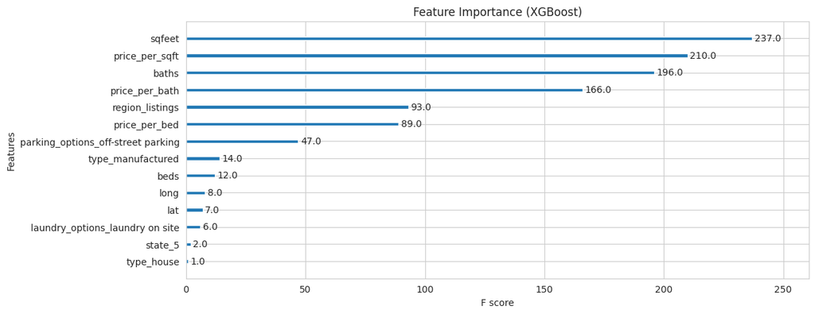

```python
# Train a quick XGBoost model to check feature importance
xgb_model_temp = xgb.XGBRegressor(n_estimators=100, learning_rate=0.05, max_depth=6, random_state=42)
xgb_model_temp.fit(X_train, y_train)

# Get feature importance
plt.figure(figsize=(10, 5))
xgb.plot_importance(xgb_model_temp, importance_type="weight", max_num_features=20)
plt.title("Feature Importance (XGBoost)")
plt.show()
```

```python
# Define weak features to drop based on importance
drop_features = ["type_house", "state_5", "laundry_options_laundry on site", "lat", "long", "beds"]

# Drop from train & test sets
X_train = X_train.drop(columns=drop_features)
X_test = X_test.drop(columns=drop_features)

print("Updated Feature List:", X_train.columns.tolist())
```

```
Updated Feature List: ['sqfeet', 'baths', 'cats_allowed', 'dogs_allowed', 'smoking_allowed', 'wheelchair_access', 'electric_vehicle_charge', 'comes_furnished', 'price_per_sqft', 'price_per_bed', 'price_per_bath', 'pets_allowed', 'total_amenities', 'region_listings', 'laundry_options_no laundry on si…
```

```python
# Define the objective function
def objective(trial):
    params = {
        "n_estimators": trial.suggest_int("n_estimators", 100, 1000, step=100),
        "learning_rate": trial.suggest_loguniform("learning_rate", 0.005, 0.1),
        "max_depth": trial.suggest_int("max_depth", 3, 10),
        "subsample": trial.suggest_float("subsample", 0.6, 1.0),
        "colsample_bytree": trial.suggest_float("colsample_bytree", 0.6, 1.0),
        "reg_alpha": trial.suggest_loguniform("reg_alpha", 1e-4, 10.0),
        "reg_lambda": trial.suggest_loguniform("reg_lambda", 1e-4, 10.0),
    }

    model = xgb.XGBRegressor(**params, random_state=42, eval_metric="rmse")

    # Train the model and manually implement early stopping
    model.fit(X_train, y_train, eval_set=[(X_test, y_test)], verbose=False)

    # Make predictions
    y_pred = model.predict(X_test)

    # Return RMSE for evaluation
    return mean_squared_error(y_test, y_pred) ** 0.5 # RMSE

# Run optimization
study = optuna.create_study(direction="minimize")
study.optimize(objective, n_trials=20)

# Get best parameters
best_params = study.best_params
print("Best XGBoost Hyperparameters:", best_params)

# Train final model with best parameters
xgb_best = xgb.XGBRegressor(**best_params, eval_metric="rmse")
xgb_best.fit(X_train, y_train)
y_pred_xgb_best = xgb_best.predict(X_test)

# Evaluate performance
mae_xgb = mean_absolute_error(y_test, y_pred_xgb_best)
rmse_xgb = mean_squared_error(y_test, y_pred_xgb_best) ** 0.5
r2_xgb = r2_score(y_test, y_pred_xgb_best)

print(f"Fine-Tuned XGBoost Performance:\nMAE: {mae_xgb:.2f}, RMSE: {rmse_xgb:.2f}, R²: {r2_xgb:.4f}")
```

[output not shown]

[output cut: 7 more lines]

```
Best XGBoost Hyperparameters: {'n_estimators': 900, 'learning_rate': 0.06396799513603198, 'max_depth': 10, 'subsample': 0.8125682229519884, 'colsample_bytree': 0.7313180869808001, 'reg_alpha': 8.640549993727436, 'reg_lambda': 0.005787706566083842}
Fine-Tuned XGBoost Performance:
MAE: 532.79, RMSE: 51877.55, R²: 0.2349
```

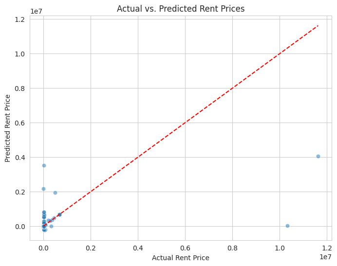

```python
plt.figure(figsize=(8, 6))
sns.scatterplot(x=y_test, y=y_pred_xgb_best, alpha=0.5)
plt.plot([y_test.min(), y_test.max()], [y_test.min(), y_test.max()], "--", color="red")
plt.xlabel("Actual Rent Price")
plt.ylabel("Predicted Rent Price")
plt.title("Actual vs. Predicted Rent Prices")
plt.show()
```

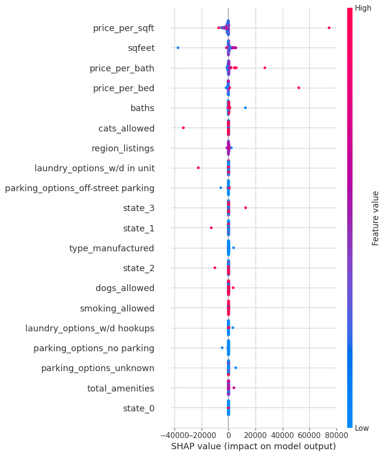

```python
# Use a smaller sample to speed up computation
sample_X = X_test.sample(n=200, random_state=42)

explainer = shap.TreeExplainer(xgb_best)
shap_values = explainer.shap_values(sample_X)

shap.summary_plot(shap_values, sample_X)
```

```python
# Define models
models = {
    "Linear Regression": LinearRegression(),
    "Random Forest": RandomForestRegressor(n_estimators=100, random_state=42),
    "LightGBM": lgb.LGBMRegressor(n_estimators=300, learning_rate=0.05),
    "CatBoost": cb.CatBoostRegressor(iterations=300, learning_rate=0.05, verbose=0),
    "XGBoost (Tuned)": xgb_best
}


# Train and evaluate each model
results = {}
for name, model in models.items():
    model.fit(X_train, y_train)
    y_pred = model.predict(X_test)

    mae = mean_absolute_error(y_test, y_pred)
    rmse = mean_squared_error(y_test, y_pred) ** 0.5
    r2 = r2_score(y_test, y_pred)

    results[name] = {"MAE": mae, "RMSE": rmse, "R²": r2}


df_results = pd.DataFrame(results).T
display(df_results)
```

```
[LightGBM] [Warning] Found whitespace in feature_names, replace with underlines
[LightGBM] [Info] Auto-choosing row-wise multi-threading, the overhead of testing was 0.067111 seconds.
You can set `force_row_wise=true` to remove the overhead.
And if memory is not enough, you can set `force_col_wise=true`.
[LightGBM] [Info] Total Bins 1324
[LightGBM] [Info] Number of data points in the train set: 277183, number of used features: 38
[LightGBM] [Info] Start training from score 1626.647269
```

|  | MAE | RMSE | R² |
| --- | --- | --- | --- |
| Linear Regression | 760.115707 | 22349.352682 | 0.857995 |
| Random Forest | 76.298240 | 14993.161722 | 0.936091 |
| LightGBM | 1146.682442 | 59824.768428 | -0.017500 |
| CatBoost | 956.220353 | 70070.425759 | -0.395860 |
| XGBoost (Tuned) | 532.793396 | 51877.551831 | 0.234877 |

### **1. Model Selection Analysis**

#### **Current Performance Comparison**

[output not shown]

### **Why is XGBoost Failing?**

#### **Hybrid Model**

- **Idea**: Use a **Linear Regression + Random Forest Ensemble**.
- **Why?**: Linear Regression does well with broad trends, while RF captures non-linear patterns.

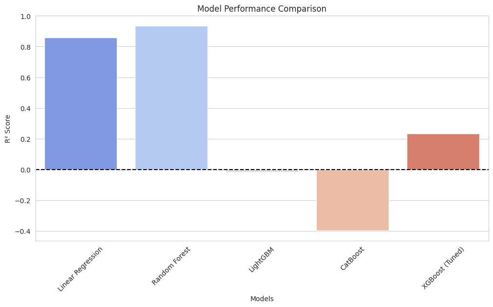

```python
# Convert results dictionary to DataFrame for visualization
df_results = pd.DataFrame(results).T.reset_index()
df_results.columns = ["Model", "MAE", "RMSE", "R²"]

# Plot Model Performance Comparison
plt.figure(figsize=(12, 6))
sns.barplot(x="Model", y="R²", data=df_results, palette="coolwarm")
plt.axhline(0, color="black", linestyle="--")
plt.xlabel("Models")
plt.ylabel("R² Score")
plt.title("Model Performance Comparison")
plt.xticks(rotation=45)
plt.show()
```

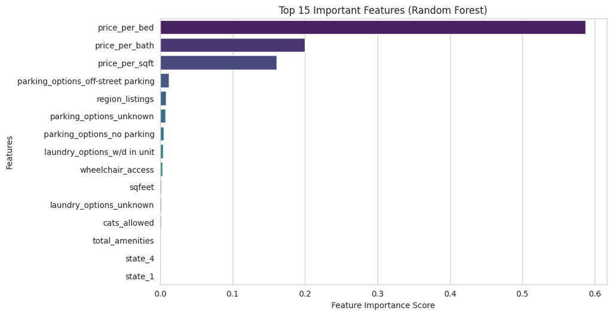

```python
# Retrieve trained Random Forest model
rf_model = models["Random Forest"]

# Extract Feature Importance
importances = rf_model.feature_importances_
feature_names = np.array(X_train.columns)  # Use correct feature set

# Sort Features by Importance
sorted_idx = np.argsort(importances)[::-1]
top_n = 15  # Select top 15 important features

# Plot Feature Importance
plt.figure(figsize=(10, 6))
sns.barplot(x=importances[sorted_idx][:top_n], y=feature_names[sorted_idx][:top_n], palette="viridis")
plt.xlabel("Feature Importance Score")
plt.ylabel("Features")
plt.title("Top 15 Important Features (Random Forest)")
plt.show()
```

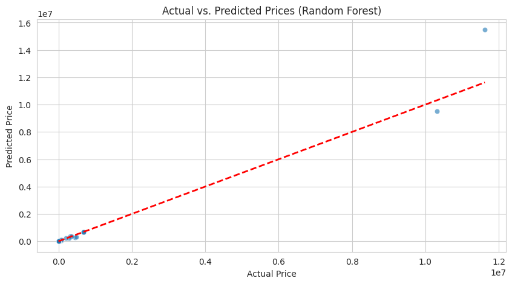

```python
# Predict using the trained Random Forest model
y_pred_rf = rf_model.predict(X_test)

# Scatter Plot: Actual vs. Predicted Prices
plt.figure(figsize=(10, 5))
sns.scatterplot(x=y_test, y=y_pred_rf, alpha=0.6)
plt.plot([min(y_test), max(y_test)], [min(y_test), max(y_test)], '--r', linewidth=2)  # Perfect Prediction Line
plt.xlabel("Actual Price")
plt.ylabel("Predicted Price")
plt.title("Actual vs. Predicted Prices (Random Forest)")
plt.show()
```

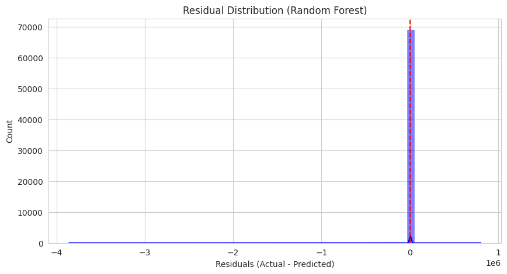

```python
# Calculate Residuals
residuals = y_test - y_pred_rf

# Residual Plot
plt.figure(figsize=(10, 5))
sns.histplot(residuals, bins=50, kde=True, color="blue")
plt.axvline(x=0, color='red', linestyle='--')
plt.xlabel("Residuals (Actual - Predicted)")
plt.title("Residual Distribution (Random Forest)")
plt.show()
```

```python
from sklearn.metrics import mean_absolute_error, mean_squared_error, r2_score

# Calculate Evaluation Metrics
mae_rf = mean_absolute_error(y_test, y_pred_rf)
rmse_rf = np.sqrt(mean_squared_error(y_test, y_pred_rf))
r2_rf = r2_score(y_test, y_pred_rf)

# Create a Performance Summary Table
model_results = pd.DataFrame({
    "Model": ["Random Forest"],
    "MAE": [mae_rf],
    "RMSE": [rmse_rf],
    "R² Score": [r2_rf]
})

display(model_results)
```

|  | Model | MAE | RMSE | R² Score |
| --- | --- | --- | --- | --- |
| 0 | Random Forest | 76.29824 | 14993.161722 | 0.936091 |

## Save the Model

```python
import joblib
joblib.dump(models["Random Forest"], "/content/drive/MyDrive/ML_Projects/Smart_Real_Estate_Insights_Engine/model/final_rent_price_model.pkl")
```

```
['/content/drive/MyDrive/ML_Projects/Smart_Real_Estate_Insights_Engine/model/final_rent_price_model.pkl']
```